# EP1162 Preliminary Analysis

Hardy Griesbauer

04/03/2020

```r
knitr::opts_chunk$set(echo = TRUE, warning = FALSE, message = FALSE,
                      fig.width=10)

# Load libraries
library(tidyverse)

# Load dataset
load(here::here("data","ep1162_Data.RData"))
load(here::here("data","ep1162_plotData.RData"))
```

## Prelim analysis

Below are some preliminary figures of the EP1162 data.

NB: this code is also posted in the github repo if you want to run it for your self. Just clone the entire repo to your local drive and take it from there.

https://github.com/hgriesbauer/EP1162

NB2: Plots 16,17, 18 and 19 were omitted from the dataset for these analyses because they were not measured in 1994 or 1997.

```r
dat<-
  dat %>%
  filter(!Plot %in% c(16,17,18,19)) # remove plots 16-19 from data for further analysis
```

This means that the following analyses are based on 15 plots.

### Number of trees by diameter class

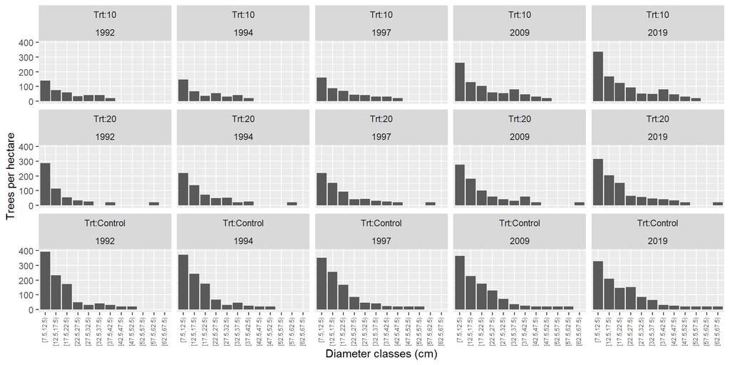

```r
# set up diameter classes
diamClass=seq(from=7.5,to=95,by=5)

dat %>%
  left_join(plotDat,by="Plot") %>%
   filter(Status=="Live") %>% # filter for live trees only
  mutate(DBH.class=cut(DBH,diamClass,ordered_result = TRUE,right=F)) %>% # assign DBH classes

  # Group and summarise
  group_by(BA.Target,Plot,Year,DBH.class) %>%
  summarise(Num.Trees=n()) %>%
  mutate(Num.Trees=Num.Trees*20) %>% # multiply to get trees per hectare

  # Generate means and SD
  ungroup() %>%
  group_by(BA.Target,Year,DBH.class) %>%
  summarise(Tree.Count.mean=mean(Num.Trees),
            Tree.Count.SD=sd(Num.Trees)) %>%

  # Add labeller column
  mutate(label=factor(paste("Trt:",BA.Target,sep=""))) %>%

  # Plotting
  ggplot()+
  aes(x=DBH.class,y=Tree.Count.mean)+
  geom_bar(stat="Identity")+
  facet_wrap(~label~Year,ncol=5)+
  theme(axis.text.x = element_text(angle = 90, hjust = 1,size=6,vjust=0.25))+
  ylab("Trees per hectare")+
  xlab("Diameter classes (cm)")
```

In this figure, Trt:10 refers to the treatment units with a target of 10m2/hectare post-harvest.

I didn’t place standard error bars on the graph. They are quite wide (high variation within treatment units).

Interesting to note that in all three treatment units, the number of trees in the smaller diameter classes actually decrease between 1992 and 1994 - will look at the plots to see where this ocurred, but could also be related to mortality in the understory?

### Trees per hectare by species and diameter class in 2019

Let’s look at species composition by treatment unit in 2019:

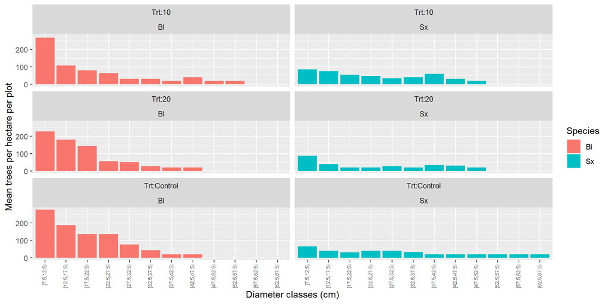

```r
dat %>%
  left_join(plotDat,by="Plot") %>% # join with plot data
   filter(Status=="Live") %>% # filter for live trees only
   mutate(DBH.class=cut(DBH,diamClass,ordered_result = TRUE,right=F)) %>% # assign DBH classes
  filter(Year==2019) %>% # filter for 2019
  filter(Species%in%c("Sx","Bl")) %>% #filter for Sx and Bl
  group_by(BA.Target,Plot,Species,DBH.class) %>%
  summarise(Spp.Plot=n()) %>% # summarise number of trees per plot by species
  mutate(Spp.Plot=Spp.Plot*20) %>%# plot multiplier to get sph

  # create means
  ungroup() %>%
  group_by(BA.Target,Species,DBH.class) %>%
  summarise(SPH=mean(Spp.Plot)) %>%

   # Add labeller column
  mutate(label=factor(paste("Trt:",BA.Target,sep=""))) %>%

  # Plotting
  ggplot()+
  aes(x=DBH.class,y=SPH,fill=Species)+
  geom_bar(stat="Identity")+
  facet_wrap(~label~Species,ncol=2)+
  theme(axis.text.x = element_text(angle = 90, hjust = 1,size=6,vjust=0.25))+
  ylab("Mean trees per hectare per plot")+
  xlab("Diameter classes (cm)")
```

A few observations:

- There are actually more spruce trees per hectare in the high-removal treatment than the other two.
- Higher Q value for Control treatment SAF compared to harvested units.

### Basal area per hectare by species and diameter class in 2019

Let’s look at basal area by species, diameter class and treatment unit in 2019:

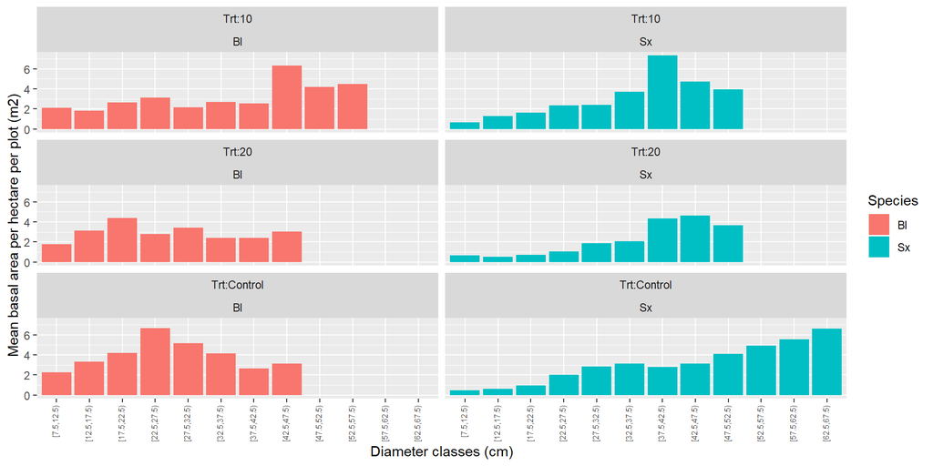

```r
dat %>%
  left_join(plotDat,by="Plot") %>% # join with plot data
   filter(Status=="Live") %>% # filter for live trees only
   mutate(DBH.class=cut(DBH,diamClass,ordered_result = TRUE,right=F)) %>% # assign DBH classes
  filter(Year==2019) %>% # filter for 2019
  filter(Species%in%c("Sx","Bl")) %>% #filter for Sx and Bl
  mutate(BA=(DBH/2/100)^2*pi) %>% # convert DBH to basal area
  group_by(BA.Target,Plot,Species,DBH.class) %>%
  summarise(BA.Plot=sum(BA)*20) %>%   # sum basal area per diam class and multiply to get per ha

  # create means
  ungroup() %>%
  group_by(BA.Target,Species,DBH.class) %>%
  summarise(BA=mean(BA.Plot)) %>%

   # Add labeller column
  mutate(label=factor(paste("Trt:",BA.Target,sep=""))) %>%

  # Plotting
  ggplot()+
  aes(x=DBH.class,y=BA,fill=Species)+
  geom_bar(stat="Identity")+
  facet_wrap(~label~Species,ncol=2)+
  theme(axis.text.x = element_text(angle = 90, hjust = 1,size=6,vjust=0.25))+
  ylab("Mean basal area per hectare per plot (m2)")+
  xlab("Diameter classes (cm)")
```

A few observations:

- Sx basal area is concentrated in the larger diameter classes.
- Bl basal area is more evenly distributed across diameter classes.

### Basal area by year and treatment

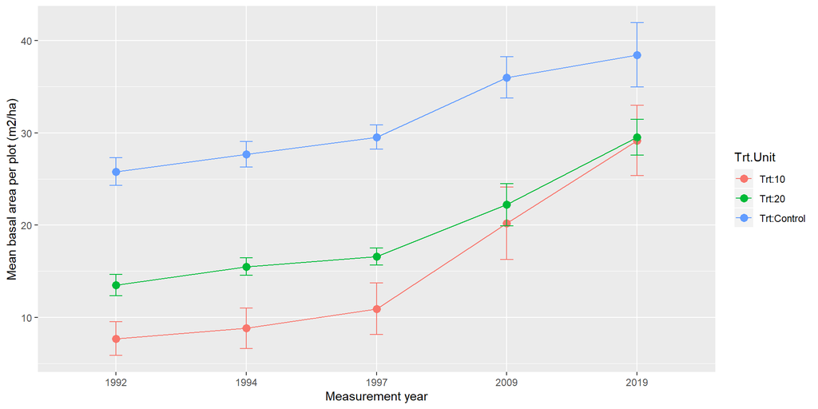

```r
dat %>%
   left_join(plotDat,by="Plot") %>% # join with plot data
  filter(Status=="Live") %>%
   mutate(DBH.class=cut(DBH,diamClass,ordered_result = TRUE,right=F)) %>% # assign DBH classes
  mutate(BA=(DBH/100/2)^2*pi) %>% # convert tree DBH to basal area
  group_by(BA.Target,Plot,Year) %>%
  summarise(BA=sum(BA)*20) %>% # multiply by 20 for BA/ha
  ungroup() %>%

  # create mean and SD
  group_by(BA.Target,Year) %>%
  summarise(BA.Mean=mean(BA),
            BA.se=sd(BA)/sqrt(length(BA))) %>% # calculate standard error of the mean

    # Add labeller column
  mutate(Trt.Unit=factor(paste("Trt:",BA.Target,sep=""))) %>%

  # # padd out the year column
  # right_join(data.frame(Year=as.factor(1992:2019)),by="Year") %>%


  # Plotting
  ggplot()+
  aes(x=Year,y=BA.Mean,color=Trt.Unit,group=Trt.Unit)+
  geom_point(size=3)+
  geom_line()+
  geom_errorbar(aes(ymin=BA.Mean-BA.se,ymax=BA.Mean+BA.se),width=0.1)+
  xlab("Measurement year")+
  ylab("Mean basal area per plot (m2/ha)")
```

I included error bars in this code.

### Basal area contribution by species

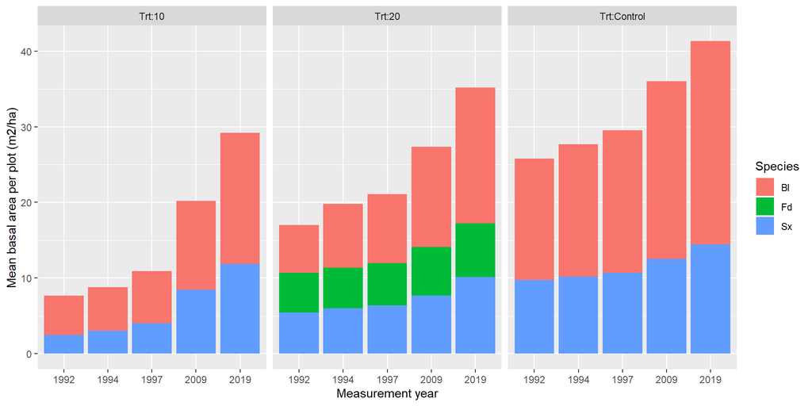

```r
dat %>%
    filter(Species!="Ep") %>% # remove birch
    filter(Status=="Live") %>% # filter for live only trees
   left_join(plotDat,by="Plot") %>% # join with plot data
   mutate(DBH.class=cut(DBH,diamClass,ordered_result = TRUE,right=F)) %>% # assign DBH classes
  mutate(BA=(DBH/100/2)^2*pi) %>% # convert tree DBH to basal area
  group_by(BA.Target,Plot,Year,Species) %>%
  summarise(BA=sum(BA)*20) %>% # multiply by 20 for BA/ha
  ungroup() %>%

  # create mean and SD
  group_by(BA.Target,Year,Species) %>%
  summarise(BA.Mean=mean(BA),
            BA.se=sd(BA)/sqrt(length(BA))) %>% # calculate standard error of the mean

    # Add labeller column
  mutate(label=factor(paste("Trt:",BA.Target,sep=""))) %>%

  # # pad out the year column
  # right_join(data.frame(Year=as.factor(1992:2019)),by="Year") %>%

  # Plotting
  ggplot()+
  aes(x=Year,y=BA.Mean,fill=Species)+
  geom_bar(stat="Identity")+
  facet_wrap(~label)+
  ylab("Mean basal area per plot (m2/ha)")+
  xlab("Measurement year")
```

*Note: I removed birch from the dataset for this figure*

A few observations:

### PBAI

Below is code to recreate Mike’s PBAI graph by initial BA:

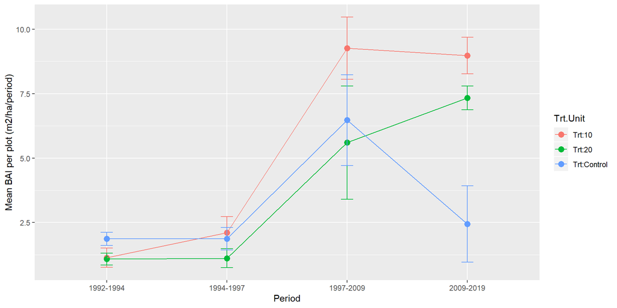

```r
dat %>%
  left_join(plotDat,by="Plot") %>% # join with plot data
   filter(Status=="Live") %>% # filter for live trees only
  mutate(BA=(DBH/2/100)^2*pi*20) %>% # convert DBH to basal area and multiply for per hectare
  dplyr::select(BA.Target,Plot,TreeID,Species,Year,BA) %>%
  group_by(BA.Target,Plot,Year) %>%
  summarise(BA.Sum=sum(BA,na.rm=T)) %>%
  pivot_wider(names_from=Year,values_from=BA.Sum) %>%
  mutate(`1992-1994`=`1994`-`1992`) %>%
  mutate(`1994-1997`=`1997`-`1994`) %>%
  mutate(`1997-2009`=`2009`-`1997`) %>%
  mutate(`2009-2019`=`2019`-`2009`) %>%

  # pivot back
  dplyr::select(BA.Target,Plot,`1992-1994`:`2009-2019`) %>%
  pivot_longer(cols=`1992-1994`:`2009-2019`,names_to="Period",values_to="PBAI") %>%
  mutate(Period=factor(Period)) %>%

  # summarise PBAI by BA.Target
  group_by(BA.Target,Period) %>%
  summarise(PBAI.mean=mean(PBAI,na.rm=T),
            PBAI.se=sd(PBAI,na.rm=T)/sqrt(length(PBAI))) %>%

    # Add labeller column
  mutate(Trt.Unit=factor(paste("Trt:",BA.Target,sep=""))) %>%

  # Plotting
  ggplot()+
  aes(x=Period,y=PBAI.mean,fill=Trt.Unit,color=Trt.Unit,group=Trt.Unit)+
  geom_point(size=3)+
  geom_line()+
  geom_errorbar(aes(ymin=PBAI.mean-PBAI.se,ymax=PBAI.mean+PBAI.se),width=0.1)+
  xlab("Period")+
  ylab("Mean BAI per plot (m2/ha/period)")
```

Graph looks similar to Mike’s original figure.

### Effect of initial BA on PBAI

Below is R code to re-create Mike’s figure of initial BA on PBAI by period

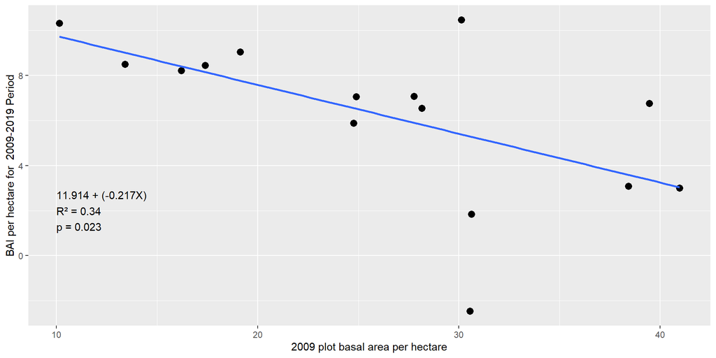

```r
pbai<- # assign output so we can plot several periods
  dat %>%
  left_join(plotDat,by="Plot") %>% # join with plot data
   filter(Status=="Live") %>% # filter for live trees only
  mutate(BA=(DBH/2/100)^2*pi*20) %>% # convert DBH to basal area and multiply for per hectare
  dplyr::select(BA.Target,Plot,TreeID,Species,Year,BA) %>%
  group_by(BA.Target,Plot,Year) %>%
  summarise(BA.Sum=sum(BA,na.rm=T)) %>%
  pivot_wider(names_from=Year,values_from=BA.Sum) %>%
  mutate(`1992-1994`=`1994`-`1992`) %>%
  mutate(`1994-1997`=`1997`-`1994`) %>%
  mutate(`1997-2009`=`2009`-`1997`) %>%
  mutate(`2009-2019`=`2019`-`2009`) %>%
  mutate(`1994-2019`=`2019`-`1994`)



  # Plotting function
pbai.Plot<-function(initYear,baPeriod,data=pbai,x=15,y=5) {

  # Linear model to extract coefficients and R2
  mod1<-
      data.frame(data[initYear],data[baPeriod]) %>%
      setNames(c("initialBA","PBAI")) %>%
      lm(PBAI~initialBA,data=.)

  text1=paste(round(broom::tidy(mod1)[1,"estimate"],3),
              " + (",
              round(broom::tidy(mod1)[2,"estimate"],3),
              "X)\n",
              "R² = ",
              round(broom::glance(mod1)[1],3),
              "\np = ",
              round(broom::glance(mod1)["p.value"],3),
              sep="")

  p1<-
    data.frame(data[initYear],data[baPeriod]) %>%
    setNames(c("initialBA","PBAI")) %>%
     # filter(PBAI>=0) %>%
      ggplot()+
    aes(x=initialBA,y=PBAI)+
    geom_point(size=3)+
    geom_text(label=text1,x=x,y=y,check_overlap=TRUE,hjust=0)+
    geom_smooth(method="lm",se=FALSE)+ # add regression line
    xlab(paste(initYear," plot basal area per hectare",sep=""))+
    ylab(paste("BAI per hectare for ",baPeriod, "Period"))

  return(p1)

}

# iteratively adjust x and y to line up text properly
pbai.Plot(initYear="2009",baPeriod="2009-2019",x=10,y=2)
```

We see a negative relationship between plot basal area and 2009-2019 PBAI. Note the outlier - this plot is a control plot that had a large Sx tree die between 2009-2019, resulting in negative PBAI for that period.

*For discussion* Although the relationship seems nonlinear negative, I think that’s mostly due to the plot (Treatment: Control Plot 3) with negative PBAI. I don’t think we would want to model plots with negative PBAI, as these are due to stand dynamics/forest health factors, and we are primarily interested in effects of treatment on growth.

With plot 3 removed, the relationship looks more linear:

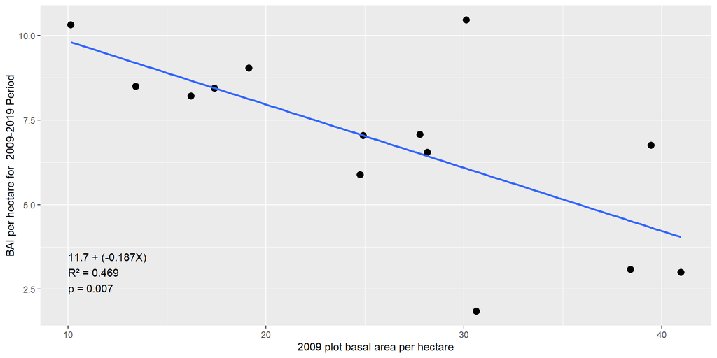

```r
pbai.2<-
  pbai %>%
  filter(Plot!=3)

pbai.Plot(initYear="2009",baPeriod="2009-2019",data=pbai.2,x=10,y=3)
```

This linear relationship doesn’t hold for periods earlier than the 2009-2019 period:

1994 period:

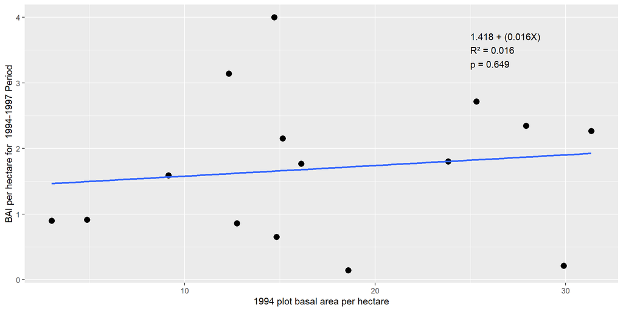

```r
pbai.Plot(initYear="1994",baPeriod="1994-1997",y=3.5,x=25)
```

1997 period:

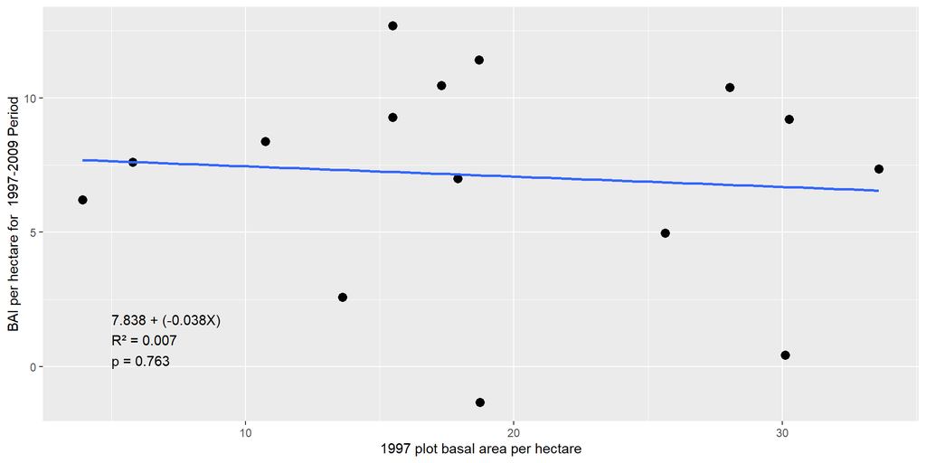

```r
pbai.Plot(initYear="1997",baPeriod="1997-2009",x=5,y=1)
```

1994-2019 period:

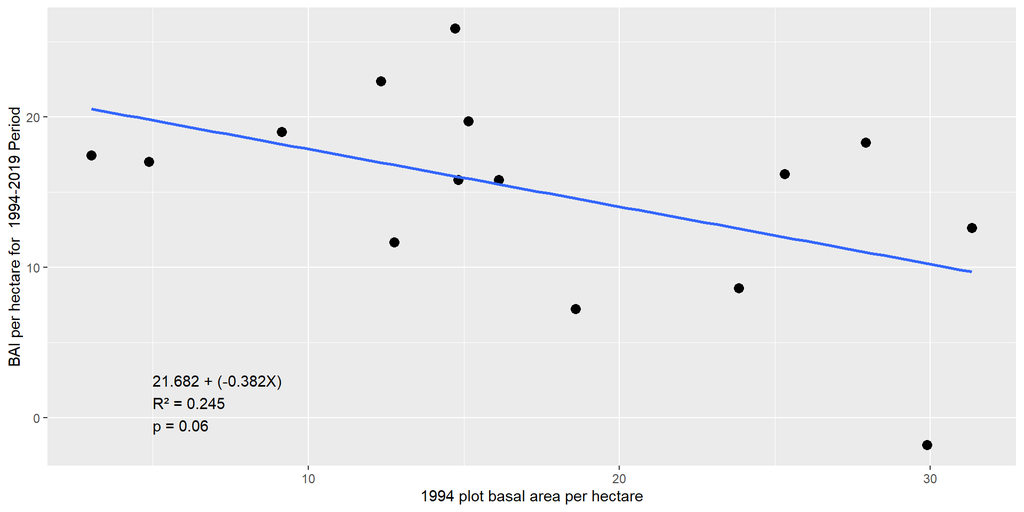

```r
pbai.Plot(initYear="1994",baPeriod="1994-2019",x=5,y=1)
```

Plot 3 is an outlier because it has a negative BAI over the 1994-2019 period. With this outlier removed, the slope would likely be p<0.05.